# Numerical skills for neuroscience

Part 1 · Functions, change and rhythms

Matteo Lisi

## Outline part 1

| A mathematical tool | A question it helps us ask |
| --- | --- |
| **Function** $y=f(x)$ | How are two quantities related? |
| **Derivative** $dy/dt$ | How quickly does something change? |
| **Fourier transform** | Which rhythms are present? |

## A function maps an input to an output

$$x\quad\longrightarrow\quad f(x)\quad\longrightarrow\quad y$$

[figure not shown]

$$f(x)=x \qquad f(x)=x^2 \qquad f(x)=\tfrac15x^3+x^2-1$$

## Function notation (example: exponential decay)

$$\underbrace{V(t)}_{\text{voltage at time }t}
=\underbrace{V_0}_{\text{starting value}}
\,e^{-t/\tau}$$

| Symbol | Read it as |
| --- | --- |
| $t$ | Input: elapsed time |
| $V(t)$ | Output: voltage relative to baseline |
| $V_0,\ \tau$ | Parameters: values that set the curve’s shape |

Check the units: $t$ and $\tau$ must use the same time unit.

## Exponentials describe growth and decay

[figure not shown]

$$\exp(x)=e^x \qquad e\approx2.718 \qquad V(t)=V_0 e^{-t/\tau}$$

## A logarithm reverses an exponential

[figure not shown]

$$\ln(e^x)=x$$

$$\ln(ab)=\ln(a)+\ln(b)$$

For real logarithms: **positive inputs**.

In R: `exp(x)` and `log(x)`.

The sum of two logarithm equal the logarithm of their product. This is useful when calculating the *joint probability* of many independent events (it is computed as the product of individual event probabilities, and it is often convenient to turn this into a sum using logarithms).

## Quiz: read the curve

**B. Slower.** It takes twice as long to reach the same fraction of $V_0$.

## The *gradient* is a difference divided by a difference

[figure not shown]

$$\frac{\Delta y}{\Delta t}
=\frac{4\ \mathrm{cm}}{2\ \mathrm{s}}
=2\ \mathrm{cm/s}$$

$\Delta$ means **change in**.

## On a curve, the gradient depends on where you are

[figure not shown]

$$f'(x)=\frac{df}{dx}
=\lim_{h\to0}\frac{f(x+h)-f(x)}{h}$$

## A derivative tells us the local direction of change

[figure not shown]

$$f(x)=x^2 \qquad\Rightarrow\qquad f'(x)=2x$$

#### Example application: differentiating gaze position to compute gaze velocity

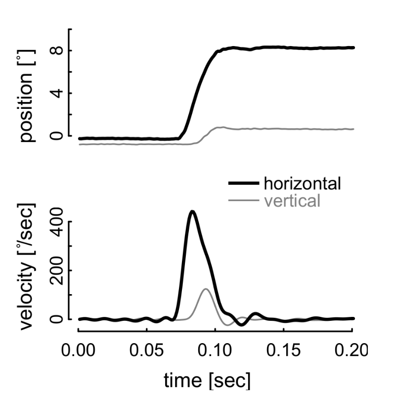

## From gaze position to gaze velocity

[figure not shown]

*Numerical* differentiation: for digital signals described by a set of points we can estimate the derivative using a finite difference approach

$$v_{i+1/2}\approx\frac{x_{i+1}-x_i}{t_{i+1}-t_i}$$

## Small measurement errors can become large derivative errors

[figure not shown]

## Probability *density* functions

Normal or Gaussian distribution: $p(x) = \frac{1}{\sigma \sqrt{2 \pi}} e^{-\frac{1}{2} \left( \frac{x - \mu}{\sigma} \right)^2}$

[figure not shown]

## Probability *mass* functions

Binomial distribution: $\Pr(k) = {n\choose k} p^k(1-p)^{n-k}$

[figure not shown]

*Note: this is a discrete function, and therefore not differentiable.*

## Trigonometric functions

Sine and cosine turn angles into oscillations

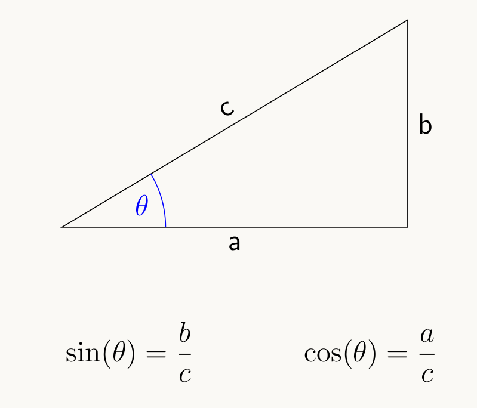

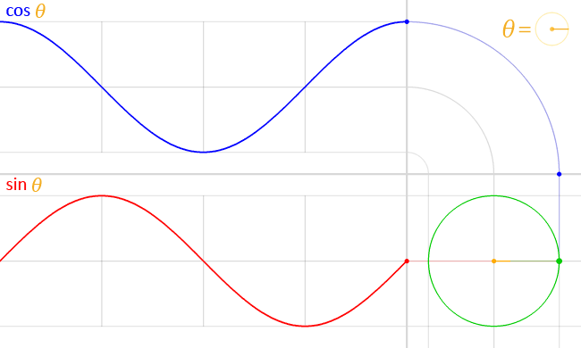

## Trigonometric functions

Sine and cosine turn angles into oscillations

[figure not shown]

$$360^\circ=2\pi\ \text{radians}$$

## 4 parameters to define a rhythm

$$y(t)=b+A\cos(2\pi f t+\phi)$$

- $b$, average (baseline)
- $A$, amplitude
- $f$, frequency
- $\phi$, phase angle

From the phase angle and frequency we can compute the time of the 1st peak: $- \frac{\phi}{2 \pi f}$

[figure not shown]

## Period and frequency are reciprocals

$$f=\frac{1}{T}$$

| One cycle takes… | Frequency | Units |
| --- | --- | --- |
| $0.1$ seconds | $10$ | Hz = cycles/second |
| $1$ day | $1$ | cycle/day |
| $28$ days | $1/28\approx0.036$ | cycles/day |

## A recording is a sequence of samples

[figure not shown]

$$f_s=\frac{1}{\Delta t} \qquad t_i=\frac{i}{f_s},\quad i=0,\ldots,N-1$$

## Sampling too slowly can disguise a rhythm

[figure not shown]

For a band-limited signal we need $f_s>2f_{\max}$.

## One signal can contain several rhythms

[figure not shown]

Synthetic temperature-like signal · 56 days · hourly samples · baseline removed here

## Adding sinusoids can build more complex shapes

[figure not shown]

A Fourier **series** describes a periodic waveform using harmonics.

## The Fourier transform changes the description

$$\underbrace{x_0,\ldots,x_{N-1}}_{\text{values over time}}
\quad\xrightarrow{\text{DFT}}\quad
\underbrace{Y_0,\ldots,Y_{N-1}}_{\text{frequency coefficients}}$$

| Term in a paper | Meaning |
| --- | --- |
| **DFT** | Discrete Fourier transform of sampled data |
| **FFT** | A fast algorithm for calculating the DFT |
| **Amplitude spectrum** | Magnitudes plotted against frequency |

## The Fourier transform changes the description

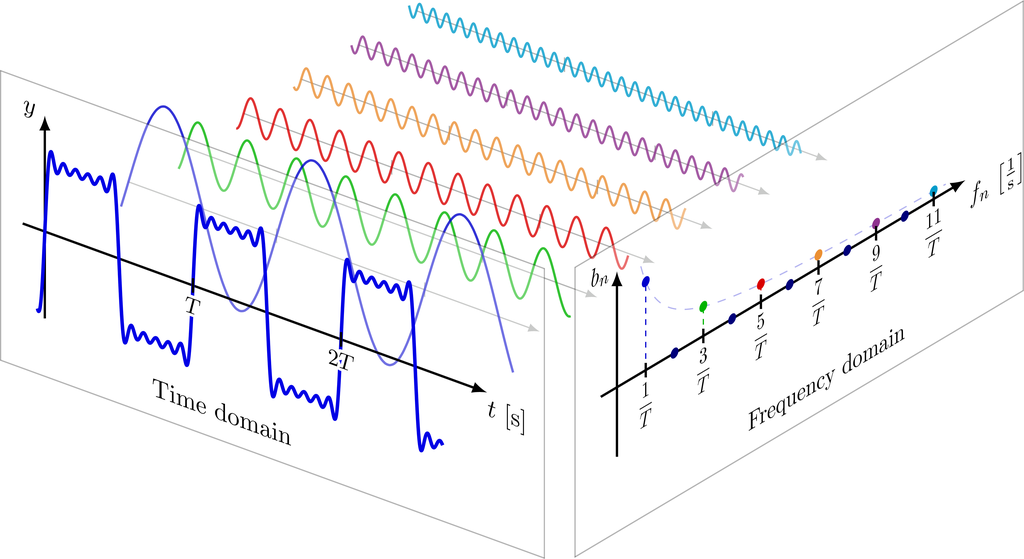

#### Monthly temperature cycle

[figure not shown]

## R code, Monthly temperature cycle example

```r
samples_per_day <- 24
N <- 56 * samples_per_day
t <- (0:(N - 1)) / samples_per_day

# 'pure' oscillations
slow <- 0.2 * cos(2 * pi * (t - 16) / 28)
daily <- 0.3 * cos(2 * pi * (t - 14 / 24))

# add the oscillations and introduce noise
x <- 36.8 + slow + daily + rnorm(N, sd = 0.2)

# perform FFT after subtracting mean (removing DC component)
Y <- fft(x - mean(x))
```

Complete, commented example: fourier_transform.R

[figure not shown]

Horizontal: **frequency**. Vertical: **amplitude**, in the signal’s units.

## Filtering selects which components to retain

[figure not shown]

$$|f|<1/24\ \text{cycles/day}\quad\Longleftrightarrow\quad T>24\ \text{days}\quad(f\ne0)$$

## Translate a methods sentence

**500 Hz** → one sample every 2 ms.

**Differentiated** → estimated how quickly position changed.

**Amplitude spectrum** → examined the strength of each frequency component.

## Three things you can now explain

| See this… | Ask this… |
| --- | --- |
| $y=f(x)$ | What are the inputs, parameters and units? |
| $dy/dt$ | Which change per unit time is being measured? |
| A spectrum | What do the axes and peaks mean? |

## Images also have frequencies

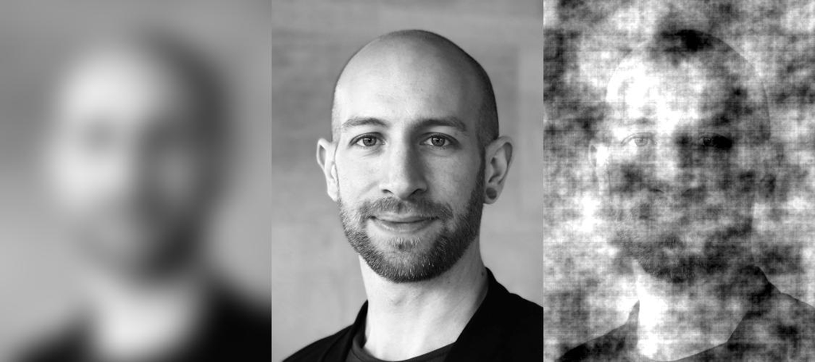

Spatial frequency: **cycles per unit distance**, rather than per second.

## Differentiating the function $f(x)=x^2$

$$\begin{align}
\frac{df}{dx} &= \lim_{h \rightarrow 0} \frac{f(x + h)-f(x)}{(x + h) - x}\\
&=\lim_{h\to 0 }\frac{(x+h)^2-x^2}{h} \\
&=\lim_{h\to 0}\frac{x^2+2xh+h^2-x^2}{h} \\
&=\lim_{h\to 0}\frac{2xh+h^2}{h} \\
&=\lim_{h\to 0}2x+h \\
&= 2x
\end{align}$$

## A small derivative reference

| Function | Derivative |
| --- | --- |
| $x^n$ | $nx^{n-1}$ |
| $e^x$ | $e^x$ |
| $\ln x$, $x>0$ | $1/x$ |
| $\sin x$ | $\cos x$ |
| $\cos x$ | $-\sin x$ |

$$\frac{d}{dt}e^{-t/\tau}=-\frac{1}{\tau}e^{-t/\tau}$$

## Integration adds up change

[figure not shown]

$$x(t_2)-x(t_1)=\int_{t_1}^{t_2}v(t)\,dt$$

## An amplitude spectrum does not show timing

[figure not shown]

Reconstruction needs **phase** as well as amplitude.

## Finite windows spread spectral energy

[figure not shown]

Spectral leakage depends on the recording window.

PS5210 · Numerical skills for neuroscience